# Communicate Data Findings

## Video Game Sales dataset

## By Mariam Alabkari

## Investigation Overview

In this investigation, I want to discover the correlations present between features in the data. The main focus was on the year, sales, genre, and gender variables.

## Dataset Overview

The Video Game Sales dataset collected from Kaggle website. The dataset consistes of information about more than 10000 Video Games, it contains 11 columns and 16291 rows. Including, name, year, genre, publisher, and global sales. The dataset contains both qualitative and quantitative types of data.

## Number of Video Games Released

This figure shows the number of video games released from 1980 to 2020. Which helps to track the number of video games that have been released over the years.

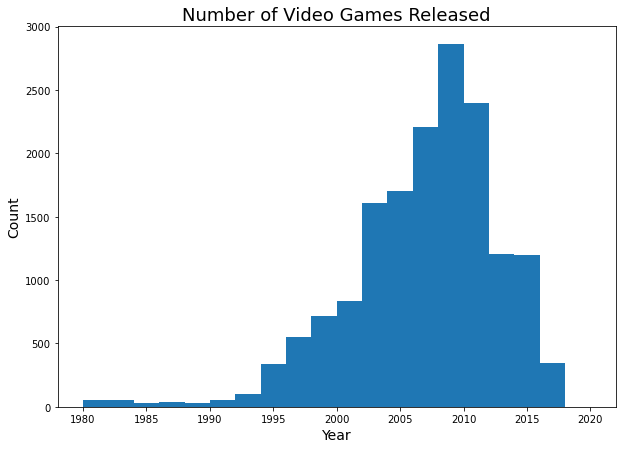

## The Platform With The Highest Releases

This figure shows the number of video games released in each platform. Which helps to distinguish the platforms with higher releases.

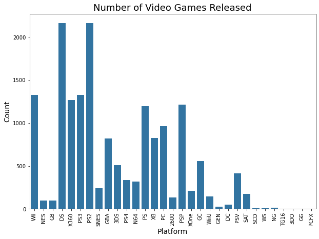

## The Genre With Higher Releases

This figure shows the number of video games released in each genre. Which helps to distinguish the genres with highest releases.

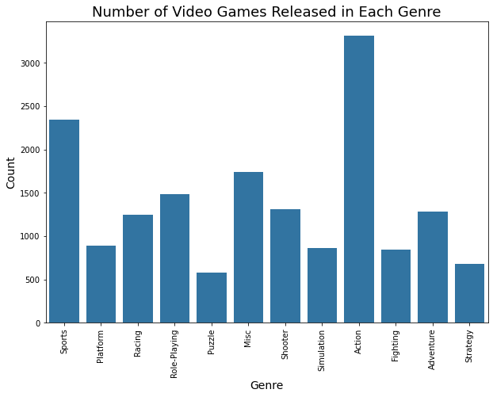

## Number of Videos Released in Each Genre Among All the Years

The figure shows what's the number of video games released, it will help to distinguish the genres with the highest releases as well as the higher release years.

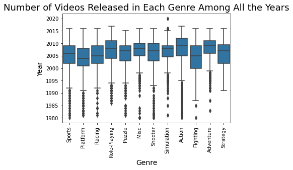

## Summary

- The number of video games started to increase year by year. However, in 2009 the number of videos games released started to decrease.
- DS and PS2 platforms have the highest number of video games released among all other platforms.
- The action video games has the highest number of released.
- There are only few puzzle video games.
- Most of the video games released after 2000.